# AbiPy v0.9.1 @IMEC

### M. Giantomassi and the AbiPy group

10th international ABINIT developer workshop  
May 31 - June 4, 2021 - Smart Working, Lockdown@BE

[figure not shown]

- These slides have been generated using [jupyter](https://jupyter.org), nbconvert and [revealjs](https://revealjs.com/)
- The notebook can be downloaded from this [github repo](https://github.com/gmatteo/abipy_abidev2021)
- To install and configure the software, follow these [installation instructions](https://github.com/abinit/abipy#getting-abipy)

Use the **Space key** to navigate through all slides and **SHIFT + Space key** to go back one slide.

[figure not shown]

## What is AbiPy?

#### Python package for:

- **Generating** ABINIT input files automatically
- **Post-processing** results extracted from *netcdf* or *text* files
- **Interfacing** ABINIT with external tools such as *vesta*, *wannier90*, *lobster*, *etc*.
- **Running** ABINIT-specific workflows on laptops as well as on HPC clusters

#### Dependencies:

- Hard deps: [pymatgen](https://github.com/materialsproject), [netcdf4](https://unidata.github.io/netcdf4-python/), [matplotlib](https://matplotlib.org/), [plotly](https://plotly.com/), [numpy](http://www.numpy.org/), [scipy](https://www.scipy.org/), [pandas](http://pandas.pydata.org/), [ipython](http://ipython.org/) …
- Soft deps: [ASE](https://wiki.fysik.dtu.dk/ase/), [phonopy](https://phonopy.github.io/phonopy/), [jupyter](https://jupyter.org/) …

NB: AbiPy can be interfaced with other packages (e.g ASE, phonopy) via **converters**.

## How to install AbiPy

Using [conda](https://conda.io/en/latest/) and the conda forge channel (*recommended*):

```
    conda install abipy --channel conda-forge
```

Since conda is not limited to python packages, one can **install ABINIT** in the same env with:

```
    conda install abinit -c conda-forge
```

Using [pip](https://pypi.org/project/pip/) and python wheels:

```
    pip install abipy --user
```

For further info see this [installation howto](http://abinit.github.io/abipy/installation.html)

## Jupyter notebooks with [examples and lessons](https://nbviewer.jupyter.org/github/abinit/abitutorials/blob/master/abitutorials/index.ipynb) inspired by the official tutorials

```python
%embed https://nbviewer.jupyter.org/github/abinit/abitutorials/blob/master/abitutorials/index.ipynb
```

[interactive chart not shown]

[figure not shown]

- Since AbiPy is not restricted to high-throughput, we'll show how to use the terminal to analyze calculations
- Well, a python script would be much more flexible but the goal here is to show that one can replace *grep*, *vim*, *gnuplot* with AbiPy
- Then we show how to use the python API for improved flexibility

No perl scripts were harmed in the making of this notebook

## Command line interface

- *abiopen.py* ➝ Open output files inside *ipython* or print/visualize file
- *abistruct.py* ➝ Operate on crystalline structures read from file
- *abicomp.py* ➝ Compare multiple files (i.e. convergence studies)
- *abiview.py* ➝ Quick visualization of output files
- *abinp.py* ➝ Generate input files for typical calculations
- *abigui.py* ➝ Start GUI in web browser

### Documentation

- `abistruct.py --help` for manpage
- `abistruct.py COMMAND --help` for help about `COMMAND`

HTML documentation available at http://abinit.github.io/abipy/scripts/index.html

### Examples

```
abistruct.py spglib si_scf_GSR.nc
abistruct.py convert si_scf_GSR.nc -f cif
abiopen.py si_scf_GSR.nc --print
```

### and many more...

[figure not shown]

# abiopen.py

#### Print results stored in FILE (more than 45 file extensions supported)

```python
!abiopen.py si_scf_GSR.nc --print
```

```
================================= File Info =================================
Name: si_scf_GSR.nc
Directory: /Users/gmatteo/git_repos/abipy_imec_2022
Size: 14.83 kb
Access Time: Mon Jun  6 23:58:53 2022
Modification Time: Mon Jun  6 23:53:36 2022
Change Time: Mon Jun  6 23:53:36 2022

================================= Structure =================================
Full Formula (Si2)
Reduced Formula: Si
abc   :   3.866975   3.866975   3.866975
angles:  60.000000  60.000000  60.000000
Sites (2)
  #  SP       a     b     c  cartesian_forces
---  ----  ----  ----  ----  -----------------------------------------------------------
  0  Si    0     0     0     [-5.89948306e-27 -1.93366149e-27  2.91016904e-27] eV ang^-1
  1  Si    0.25  0.25  0.25  [ 5.89948306e-27  1.93366149e-27 -2.91016904e-27] eV ang^-1

Abinit Spacegroup: spgid: 227, num_spatial_symmetries: 48, has_timerev: True, symmorphic: True

Stress tensor (Cartesian coordinates in GPa):
[[5.21161758e+00 7.86452261e-11 0.00000000e+00]
 [7.86452261e-11 5.21161758e+00 0.00000000e+00]
 [0.00000000e+00 0.00000000e+00 5.21161758e+00]]

Pressure: -5.212 (GPa)
Energy: -241.23647031 (eV)

============================== Electronic Bands ==============================
Number of electrons: 8.0, Fermi level: 5.598 (eV)
nsppol: 1, nkpt: 29, mband: 8, nspinor: 1, nspden: 1
smearing scheme: none (occopt 1), tsmear_eV: 0.272, tsmear Kelvin: 3157.7
Direct gap:
    Energy: 2.532 (eV)
    Initial state: spin: 0, kpt: [+0.000, +0.000, +0.000], weight: 0.002, band: 3, eig: 5.598, occ: 2.000
    Final state:   spin: 0, kpt: [+0.000, +0.000, +0.000], weight: 0.002, band: 4, eig: 8.130, occ: 0.000
Fundamental gap:
    Energy: 0.562 (eV)
    Initial state: spin: 0, kpt: [+0.000, +0.000, +0.000], weight: 0.002, band: 3, eig: 5.598, occ: 2.000
    Final state:   spin: 0, kpt: [+0.375, +0.375, +0.000], weight: 0.012, band: 4, eig: 6.161, occ: 0.000
Bandwidth: 11.856 (eV)
Valence maximum located at kpt index 0:
    spin: 0, kpt: [+0.000, +0.000, +0.000], weight: 0.002, band: 3, eig: 5.598, occ: 2.000
Conduction minimum located at kpt index 17:
    spin: 0, kpt: [+0.375, +0.375, +0.000], weight: 0.012, band: 4, eig: 6.161, occ: 0.000

TIP: Use `--verbose` to print k-point coordinates with more digits
```

#### To produce a predefined set of matplotlib figures, use:

```
abiopen.py mgb2_kpath_FATBANDS.nc --expose --seaborn
```

[figure not shown]

#### Replace *--expose* with *--notebook* to generate a jupyter notebook with predefined python code

## To visualize all the results inside the web browser, use

```
abiopen.py out_GRUNS.nc --expose-web # -ew for the short version
```

[figure not shown]

#### Convert structure from netcdf format to CIF (*abivars*, *xsf*, *poscar*, *qe*, *siesta*, *wannier90*, *json*)

```python
!abistruct.py convert si_scf_GSR.nc -f cif
```

```
# generated using pymatgen
data_Si
_symmetry_space_group_name_H-M   'P 1'
_cell_length_a   3.86697464
_cell_length_b   3.86697464
_cell_length_c   3.86697464
_cell_angle_alpha   60.00000000
_cell_angle_beta   60.00000000
_cell_angle_gamma   60.00000000
_symmetry_Int_Tables_number   1
_chemical_formula_structural   Si
_chemical_formula_sum   Si2
_cell_volume   40.88829233
_cell_formula_units_Z   2
loop_
 _symmetry_equiv_pos_site_id
 _symmetry_equiv_pos_as_xyz
  1  'x, y, z'
loop_
 _atom_site_type_symbol
 _atom_site_label
 _atom_site_symmetry_multiplicity
 _atom_site_fract_x
 _atom_site_fract_y
 _atom_site_fract_z
 _atom_site_occupancy
  Si  Si0  1  0.00000000  0.00000000  0.00000000  1
  Si  Si1  1  0.25000000  0.25000000  0.25000000  1
```

#### Are you still using *cut3d* to export the structure in a format that other applications can understand?

```
abistruct.py visualize run_si02.abi
```

[figure not shown]

#### Supports also *ovito*, *xcrysden*, *vtk*, *mayavi*, *matplotlib* (Use *--application* option)

#### Need to call *anaddb* to compute and visualize ph-bands and DOS from DDB?

```
abiview.py ddb ZnSe_hex_qpt_DDB --seaborn
```

[figure not shown]

#### Add --phononwebsite to visualize data on the [phononwebsite](http://henriquemiranda.github.io/phononwebsite/) by Henrique

```python
!abiview.py --help
```

```
usage: abiview.py [-h] [-V]
                  {structure,hist,data,dirviz,ebands,skw,fs,ifermi_fs,ddb,ddb_vs,ddb_ir,ddb_asr,ddb_dipdip,ddb_quad,ddb_isodistort_ph,ddb_ifc,ddb_qpt,phbands,lobster,denpot}
                  ...

optional arguments:
  -h, --help            show this help message and exit
  -V, --version         show program's version number and exit

subcommands:
  Valid subcommands

  {structure,hist,data,dirviz,ebands,skw,fs,ifermi_fs,ddb,ddb_vs,ddb_ir,ddb_asr,ddb_dipdip,ddb_quad,ddb_isodistort_ph,ddb_ifc,ddb_qpt,phbands,lobster,denpot}
                        sub-command help
    structure           Visualize the structure with the specified visualizer.
                        Requires external app or optional python modules
                        (mayavi, vtk)
    hist                Visualize structural relaxation/molecular-dynamics run
                        from data stored in the HIST.nc file. Requires mayavi.
    data                Extract data from a generic text file with results in
                        tabular format and plot data with matplotlib. Multiple
                        datasets are supported. No attempt is made to handle
                        metadata (e.g. column name)
    dirviz              Visualize directory tree with graphviz.
    ebands              Plot electronic bands if file contains high-symmetry
                        k-path or DOS if k-sampling. Accept any file with
                        ElectronBands e.g. GSR.nc, WFK.nc, ...
    skw                 Interpolate energies in k-space along a k-path with
                        star-function methods Note that the interpolation will
                        likely fail if there are symmetrical k-points in the
                        input set of k-points so it's recommended to call this
                        method with energies obtained in the IBZ. Accept any
                        file with ElectronBands e.g. GSR.nc, WFK.nc, ...
    fs                  Extract eigenvalues in the IBZ from file and visualize
                        Fermi surface with the external application specified
                        via --appname
    ifermi_fs           Use ifermi package to visualize the Fermi surface.
                        Requires netcdf file with energies in the IBZ. See
    ddb                 Invoke Anaddb to compute phonon bands and DOS from the
                        DDB, plot the results.
    ddb_vs              Compute speed of sound by fitting phonon frequencies
```

[output cut: 71 more lines]

```
                                               Plot results with matplotlib (default) or plotly (--plotly)
    abiview.py ddb_qpt -q 0 0.5 0         ==>  Compute ph-frequencies at the selected q-point without passing
                                               through the Fourier interpolation of the interatomic force constants.
    abiview.py ddb_ifc                    ==>  Visualize interatomic force constants in real space.
    abiview.py phbands out_PHBST.nc -web  ==>  Visualize ph-bands and displacements with phononwebsite.

###############
# Miscelleanous
###############

  abiview.py dirviz DIRECTORY            ==> Visualize directory tree with graphviz.
  abiview.py lobster DIRECTORY           ==> Visualize Lobster results.

Use `abiview.py --help` for help and `abiview.py COMMAND --help` to get the documentation for `COMMAND`.
Use `-v` to increase verbosity level (can be supplied multiple times e.g -vv).
```

#### Using *ElectronBandsPlotter* to visualize multiple band structures:

```
abicomp.py ebands *_GSR.nc
```

[figure not shown]

## AbiPy API

[figure not shown]

## AbiPy plots with matplotlib

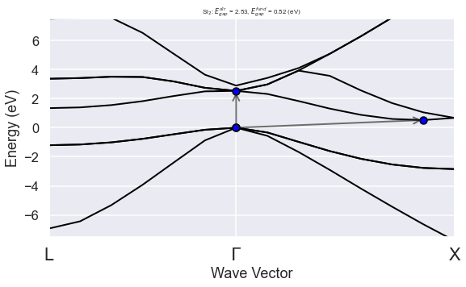

```python
gsr = abiopen("si_nscf_GSR.nc")
gsr.ebands.plot(with_gaps=True);
```

## AbiPy plots with plotly

```python
gsr.ebands.plotly(with_gaps=True);  # obj.plot becomes obj.plotly
```

[interactive chart not shown]

## To upload the plotly figure to the [chart studio server](https://chart-studio.plotly.com/~gmatteo/214), use:

```
gsr.ebands.plotly(with_gaps=True, chart_studio=True);
```

[figure not shown]

#### Users can finally customize the AbiPy plot without changing the python code 🎉

## Interactive 3d plots with plotly:

```python
gsr.ebands.kpoints.plotly(title="k-path in 3d with plotly");
```

[interactive chart not shown]

## and, ça va sans dire, phonons from DDB with plotly:

```python
znse_ddb = abilab.abiopen("ZnSe_hex_qpt_DDB")

phbst_file, phdos_file = znse_ddb.anaget_phbst_and_phdos_files()
phbands, phdos = phbst_file.phbands, phdos_file.phdos

phbands.plotly_with_phdos(phdos, units="cm-1", title="ZnSe Phonon bands + DOS in cm-1");
```

[interactive chart not shown]

## Quick intro to AbiPy Flows and selected examples

[figure not shown]

## ⚠️ There are two different workflow infrastructures:

#### Internal AbiPy implementation (*abipy.flowtk modules*):

- ✅ Lightweigth, **no database required**
- ✅ Designed for rapid prototyping and/or for supporting advanced ABINIT capabilities
- ❌ No explicit support for high-throughput (HT) applications.

#### [AbiFlows](https://github.com/abinit/abiflows) package (requires Fireworks and MongoDB database)

- ✅ **HT-oriented**: use *MongoDB* to store workflow status and results for further analysis
- ✅ **High-level API** designed for HT applications (e.g. [phonon calculations for the materials project](https://www.nature.com/articles/sdata201865))
- ❌ Not all the *flowtk* workflows are immediately available in *AbiFlows*.

NB: There's an ongoing effort to reimplement AbiFlows in terms of the [atomate framework](https://github.com/hackingmaterials/atomate). In this talk, we will mainly discuss the **new features available in abipy.flowtk**.

## [Effective masses with DFPT](https://abinit.github.io/abipy/flow_gallery/run_effmass_dfpt.html#sphx-glr-flow-gallery-run-effmass-dfpt-py)

#### This flow performs:

- GS-SCF run followed by NSCF run with **k**-path to locate band edges automatically
- Compute $\epsilon^{\alpha\beta}_{n\bf{k}}$ and the effective mass tensor at the band edges using $|u_{n\mathbf{k}}\rangle$, and the **k**-derivatives $|u_{n\mathbf{k}}^\alpha\rangle$ $H^\alpha_{\mathbf{k}}$, $H^{\alpha\beta}_{\mathbf{k}}$
- For the formalism, see J. Laflamme Janssen, et. al. Phys. Rev. B 93, 205147
- More that 1k systems already computed by J. C. Abreu.

#### Python API:

```
flow = flowtk.Flow("flow_effmass_dfpt")

# Build input for GS SCF calculation.
scf_input = make_scf_input()

# This object implements all the worflow logic
from abipy.flowtk.effmass_works import EffMassAutoDFPTWork
work = EffMassAutoDFPTWork.from_scf_input(scf_input)

flow.register_work(work)
```

## Dependency Graph

[figure not shown]

- To run the flow with the high-level interface, use: *run_effmass_dfpt.py --sheduler*
- *autoparal* algorithm:
  - select "optimal" Ncpus for each task
  - set MPI-related variables in the input
  - submit tasks and start monitoring
  - indipendent tasks are executed in parallel
- Support for *bluegene*, *moab*, *pbspro*, *sge*, *shell*, *slurm*, *torque*
- Restart capabilities (*e.g.* timeout limit) and error handlers

### To generate a GS-SCF input, one can use factory functions (HT-oriented)

```python
from abipy.abio.factories import gs_input

gs_input(structure="si.cif", pseudos="14si.pspnc", ecut=8)
```

##############################################  
#### SECTION: basic  
##############################################  
ecut 8  
ngkpt 8 8 8  
shiftk 0.5 0.5 0.5  
nshiftk 1  
kptopt 1  
nsppol 2  
nband 16  
occopt 3  
tolvrs 1e-08  
##############################################  
#### SECTION: files  
##############################################  
indata_prefix indata/in  
tmpdata_prefix tmpdata/tmp  
outdata_prefix outdata/out  
pseudos /Users/gmatteo/git_repos/abipy_imec_2022/14si.pspnc  
##############################################  
#### SECTION: gstate  
##############################################  
spinat  
0.0 0.0 0.6  
0.0 0.0 0.6  
chksymbreak 0  
nspinor 1  
nspden 2  
charge 0.0  
tsmear 0.0036749322175655 Ha  
##############################################  
#### STRUCTURE  
##############################################  
natom 2  
ntypat 1  
typat 1 1  
znucl 14  
xred  
0.0000000000 0.0000000000 0.0000000000  
0.2500000000 0.2500000000 0.2500000000  
acell 1.0 1.0 1.0  
rprim  
6.3285005244 0.0000000000 3.6537614813  
2.1095001748 5.9665675141 3.6537614813  
0.0000000000 0.0000000000 7.3075229627

## or build it from scratch if full controll is wanted:

```python
other_inp = abilab.AbinitInput(structure="si.cif", pseudos="14si.pspnc")

other_inp.set_vars(ecut=8, nsppol=2, toldfe=1e-8)
other_inp.set_autokmesh(8)

other_inp
```

##############################################  
#### SECTION: basic  
##############################################  
ecut 8  
nsppol 2  
toldfe 1e-08  
ngkpt 8 8 8  
kptopt 1  
nshiftk 4  
shiftk  
0.5 0.5 0.5  
0.5 0.0 0.0  
0.0 0.5 0.0  
0.0 0.0 0.5  
##############################################  
#### SECTION: files  
##############################################  
indata_prefix indata/in  
tmpdata_prefix tmpdata/tmp  
outdata_prefix outdata/out  
pseudos /Users/gmatteo/git_repos/abipy_imec_2022/14si.pspnc  
##############################################  
#### STRUCTURE  
##############################################  
natom 2  
ntypat 1  
typat 1 1  
znucl 14  
xred  
0.0000000000 0.0000000000 0.0000000000  
0.2500000000 0.2500000000 0.2500000000  
acell 1.0 1.0 1.0  
rprim  
6.3285005244 0.0000000000 3.6537614813  
2.1095001748 5.9665675141 3.6537614813  
0.0000000000 0.0000000000 7.3075229627

### Obviously, we used an AbiPy [script](http://abinit.github.io/abipy/flow_gallery/run_eph_pot.html#sphx-glr-flow-gallery-run-eph-pot-py) to automate most of the steps:

[figure not shown]

NB: This is a simplified version with just 2 **q**-points in the path. In our work, we used 278 points.

## How to use AbiPy panels inside jupyter notebooks

#### To build a panel GUI inside the notebook, call the `get_panel` method:

```python
ddb = abilab.abiopen("ZnSe_hex_qpt_DDB")

#abilab.abipanel(); # Important
ddb.get_panel()
```

[interactive chart not shown]

Don't be surprised if you start to click buttons and nothing happens in the GUI! One needs a python backend to execute the callbacks triggered by the widgets.

## Documentation for these new features available at:

```python
%embed https://abinit.github.io/abipy/graphical_interface.html
```

[interactive chart not shown]

## How to run AbiPy Flows

[figure not shown]

## In order to run a *Flow*, we need two configurations files:

1. [*scheduler.yml*](http://abinit.github.io/abipy/workflows/taskmanager.html#how-to-configure-the-scheduler) providing:
   - scheduler parameters such as *days*, *hours*, *minutes*, *max_njobs_inqueue*, *max_ncores_used*, …
1. [*manager.yml*](http://abinit.github.io/abipy/workflows/taskmanager.html) providing:
   - list of shell commands to be executed before running ABINIT
   - list of modules to load
   - options for the queue manager (*bluegene*, *moab*, *pbspro*, *sge*, *shell*, *slurm*, *torque*)

See [this page](http://abinit.github.io/abipy/workflows/manager_examples.html) for examples or use the [abidoc.py](http://abinit.github.io/abipy/scripts/abidoc.html) script and the syntax:

- *abidoc.py scheduler*
- *abidoc.py manager*
- *abidoc.py manager slurm*

### How to run calculations?

The simplest way to start the scheduler from the shell is via the syntax:

```
run_elastic.py --scheduler # -s for the short option
```

For non-trivial *Flows*, we suggest to put the scheduler in background and use `nohup` so that we can disconnect from the shell session without killing the scheduler.

```
nohup run_elastic.py --s > log 2> err &
```

Obviously, it is possible to submit a Slurm script that executes the script on the compute note with 1 core.

To interact with the Flow, one can also use the [abirun.py](https://abinit.github.io/abipy/scripts/abirun.html) script, *e.g*:

```
abirun.py FLOWDIR status
```